# Styrkeprøven: Lillehammer -> Oslo Cyclosportive

Ryan Nelson

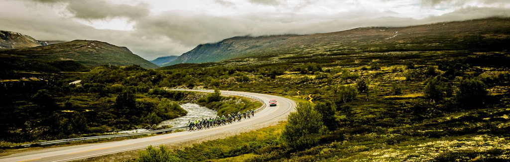

# Overview

On June 17th, 2017, the 16th edition of the [Styrkeprøven](http://styrkeproven.no/en/frontpage) Cyclosportive will take place. With different starting points on the way to Oslo, the following races and their respective distances are possible:

| Route | Distance | Elevation Gain |
| --- | --- | --- |
| Trondheim - Oslo | 543 km | 3627 m |
| Kvam - Oslo | 279 km | 1655 m |
| Lillehammer - Oslo | 191 km | 1327 m |
| Gjøvik - Oslo | 136 km | 912 m |
| Eidsvoll - Oslo | 63 km | 455 m |

This R Notebook is my look at the Lillehammer to Oslo route, at a distance of 191 kilometers.

# The Data: Lillehammer to Oslo

To analyze the course for the race, We need to acquire the data describing the course. This is available as a .GPX file on [the course site](http://styrkeproven.no/en/races/lillehammer). GPX is an XML file format used for geographical data, and is very commonly used in cycling as a file format for both recording rides, and generating routes one can follow. For ease of use (and because the library readGPX is currently not available for R 3.3.1), I downloaded it as a .CSV file for ease of analysis.

```r
geodf <- read.csv("lillehammer.csv", sep = ";")
```

Now that we have the raw geographical points imported, we’re going to use a helper function to assist in creating vectors with starts and ends between each point so that we can route it. The helper function code comes from https://rcrastinate.blogspot.de/2014/09/stay-on-track-plotting-gps-tracks-with-r.html, so all credit goes to them for the cool work there.

```r
library(raster)

shift.vec <- function (vec, shift) {
  if(length(vec) <= abs(shift)) {
    rep(NA ,length(vec))
  }else{
    if (shift >= 0) {
      c(rep(NA, shift), vec[1:(length(vec)-shift)]) }
    else {
      c(vec[(abs(shift)+1):length(vec)], rep(NA, abs(shift))) } } }

# Shift vectors for lat and lon so that each row also contains the next position.
geodf$lat.p1 <- shift.vec(geodf$lat, -1)
geodf$lon.p1 <- shift.vec(geodf$lon, -1)

# Calculate distances (in metres) using the function pointDistance from the 'raster' package.
# Parameter 'lonlat' has to be TRUE!
geodf$dist.to.prev <- apply(geodf, 1, FUN = function (row) {
  pointDistance(c(as.numeric(row["lat.p1"]),
  as.numeric(row["lon.p1"])),
                c(as.numeric(row["lat"]), as.numeric(row["lon"])),
                lonlat = T)
})
```